# NKX2-2 as a Prognostic Biomarker in Ewing Sarcoma

Survival Analysis of an Independent Cohort (GSE63157)

Musfirah

17/07/2026

# 1. Introduction

NKX2-2 was previously identified in our DESeq2 differential expression analysis (Ewing sarcoma vs. liposarcoma, GSE2553) as a top upregulated gene and a known diagnostic marker of Ewing sarcoma. Diagnostic value, however, does not automatically imply prognostic value — a marker that distinguishes tumor types is a different biological question from a marker that predicts patient outcome within a single tumor type. This report tests whether NKX2-2 expression level is associated with survival outcomes in an independent Ewing sarcoma cohort.

**Dataset:** GSE63157 — Children’s Oncology Group (COG) cohort of localized Ewing sarcoma patients, diagnosed after 1994, treated under COG protocols (AEWS0031, INT-0154). This dataset has been independently used as validation data in multiple peer-reviewed prognostic studies, supporting confidence in its clinical annotation.

**Endpoints analyzed:**

- **Overall Survival (OS)** — time to death from any cause
- **Event-Free Survival (EFS)** — time to relapse or death

# 2. Methods

## 2.1 Data acquisition and cleaning

Clinical and expression data were downloaded via `GEOquery::getGEO()`. Survival status/time fields were extracted from sample characteristics and recoded to standard 0/1 event conventions (Alive/No event = 0, Dead/Relapse = 1). One sample with a Second Malignant Neoplasm (SMN) event was excluded from the EFS analysis, as this represents a competing risk rather than a relapse of the primary tumor, and standard KM/Cox methods are not designed to handle competing risks without explicit modeling.

## 2.2 Gene expression mapping

GSE63157 was profiled on an Affymetrix Human Exon 1.0 ST array (GPL5175), which annotates probes via a compound `gene_assignment` text field rather than a direct gene symbol column. NKX2-2 was mapped by pattern-matching this field; a single unambiguous probe (ID 3900545) was identified.

## 2.3 Statistical analysis

Patients were divided into High/Low expression groups by median split. Kaplan-Meier curves were compared using the log-rank test. Cox proportional hazards regression was used to estimate hazard ratios for continuous expression, both unadjusted and adjusted for sex and tumor site. The proportional hazards assumption was tested via `cox.zph()`; where violated, models were refit stratified by the offending covariate. Tumor site was collapsed to a 2-level variable (Extremity vs. Axial/Other) due to small cell sizes in the original 3-level classification (Pelvis, n=5-6).

```r
gse <- getGEO("GSE63157", GSEMatrix = TRUE, destdir = "~/bioinformatics/data/")
eset <- gse[[1]]
expr <- exprs(eset)
fdata <- fData(eset)

nkx_probes <- rownames(fdata)[grepl("// NKX2-2 //", fdata$gene_assignment, fixed = TRUE)]
nkx_expr <- expr[nkx_probes, ]

expr_df <- data.frame(sample_id = names(nkx_expr),
                       NKX2_2_expression = as.numeric(nkx_expr))

os_df  <- read.csv("~/bioinformatics/results/GSE63157/GSE63157_OS_clean.csv",  stringsAsFactors = FALSE)
efs_df <- read.csv("~/bioinformatics/results/GSE63157/GSE63157_EFS_clean.csv", stringsAsFactors = FALSE)

os_df  <- os_df  %>% inner_join(expr_df, by = "sample_id")
efs_df <- efs_df %>% inner_join(expr_df, by = "sample_id")

os_df$NKX2_2_group  <- ifelse(os_df$NKX2_2_expression  > median(os_df$NKX2_2_expression),  "High", "Low")
efs_df$NKX2_2_group <- ifelse(efs_df$NKX2_2_expression > median(efs_df$NKX2_2_expression), "High", "Low")

os_df$sex   <- factor(os_df$sex)
efs_df$sex  <- factor(efs_df$sex)
os_df$tumor_site_simple  <- factor(ifelse(os_df$tumor_site   == "Extremity", "Extremity", "Axial_Other"))
efs_df$tumor_site_simple <- factor(ifelse(efs_df$tumor_site  == "Extremity", "Extremity", "Axial_Other"))
```

**Cohort sizes:** 46 patients with OS data (14 deaths), 45 patients with EFS data (17 relapses).

# 3. Results

## 3.1 Kaplan-Meier Survival Curves

### Overall Survival

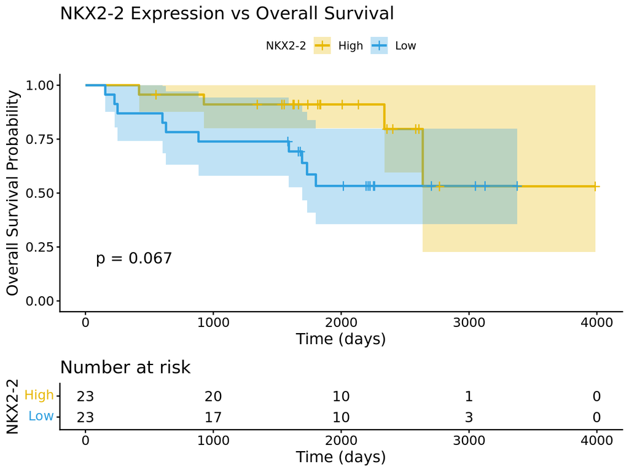

```r
os_surv <- Surv(time = os_df$os_time, event = os_df$os_event)
os_fit  <- survfit(os_surv ~ NKX2_2_group, data = os_df)

ggsurvplot(os_fit, data = os_df, pval = TRUE, risk.table = TRUE, conf.int = TRUE,
           palette = c("#E7B800", "#2E9FDF"),
           xlab = "Time (days)", ylab = "Overall Survival Probability",
           title = "NKX2-2 Expression vs Overall Survival",
           legend.title = "NKX2-2", legend.labs = c("High", "Low"))
```

### Event-Free Survival

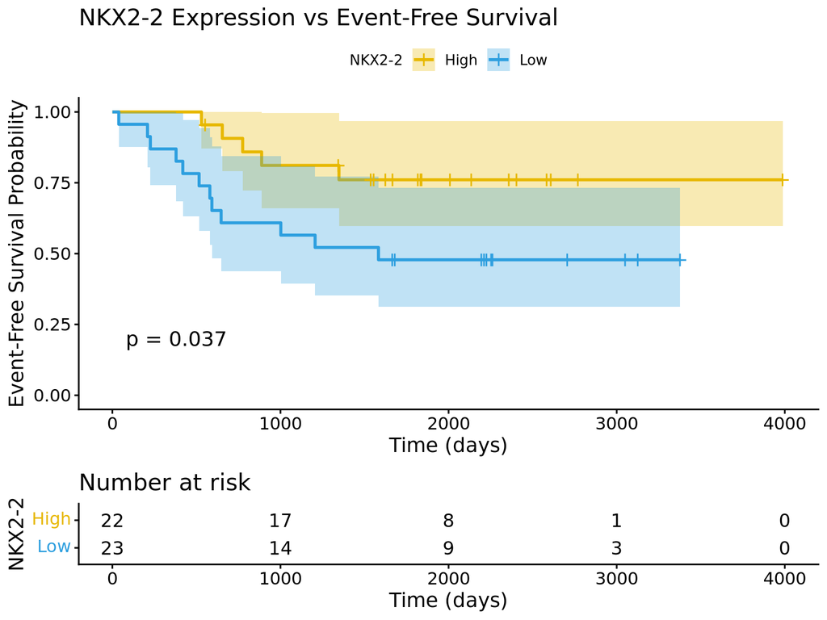

```r
efs_surv <- Surv(time = efs_df$efs_time, event = efs_df$efs_event)
efs_fit  <- survfit(efs_surv ~ NKX2_2_group, data = efs_df)

ggsurvplot(efs_fit, data = efs_df, pval = TRUE, risk.table = TRUE, conf.int = TRUE,
           palette = c("#E7B800", "#2E9FDF"),
           xlab = "Time (days)", ylab = "Event-Free Survival Probability",
           title = "NKX2-2 Expression vs Event-Free Survival",
           legend.title = "NKX2-2", legend.labs = c("High", "Low"))
```

Low NKX2-2 expression was associated with significantly worse event-free survival (log-rank p = 0.037) and a non-significant trend toward worse overall survival (log-rank p = 0.067).

## 3.2 Cox Proportional Hazards Regression

```r
cox_os  <- coxph(os_surv  ~ NKX2_2_expression + tumor_site_simple + strata(sex), data = os_df)
cox_efs <- coxph(efs_surv ~ NKX2_2_expression + tumor_site_simple + strata(sex), data = efs_df)

summary(cox_os)
```

```
## Call:
## coxph(formula = os_surv ~ NKX2_2_expression + tumor_site_simple +
##     strata(sex), data = os_df)
##
##   n= 46, number of events= 14
##
##                               coef exp(coef) se(coef)      z Pr(>|z|)
## NKX2_2_expression          -0.1956    0.8223   0.1275 -1.535    0.125
## tumor_site_simpleExtremity -1.2466    0.2875   1.0467 -1.191    0.234
##
##                            exp(coef) exp(-coef) lower .95 upper .95
## NKX2_2_expression             0.8223      1.216   0.64051     1.056
## tumor_site_simpleExtremity    0.2875      3.479   0.03695     2.236
##
## Concordance= 0.766  (se = 0.067 )
## Likelihood ratio test= 4.49  on 2 df,   p=0.1
## Wald test            = 3.93  on 2 df,   p=0.1
## Score (logrank) test = 4.43  on 2 df,   p=0.1
```

```r
summary(cox_efs)
```

```
## Call:
## coxph(formula = efs_surv ~ NKX2_2_expression + tumor_site_simple +
##     strata(sex), data = efs_df)
##
##   n= 45, number of events= 17
##
##                               coef exp(coef) se(coef)      z Pr(>|z|)
## NKX2_2_expression          -0.1826    0.8331   0.1252 -1.459    0.145
## tumor_site_simpleExtremity -0.7786    0.4591   0.7593 -1.025    0.305
##
##                            exp(coef) exp(-coef) lower .95 upper .95
## NKX2_2_expression             0.8331      1.200    0.6518     1.065
## tumor_site_simpleExtremity    0.4591      2.178    0.1037     2.033
##
## Concordance= 0.686  (se = 0.074 )
## Likelihood ratio test= 3.12  on 2 df,   p=0.2
## Wald test            = 3.05  on 2 df,   p=0.2
## Score (logrank) test = 3.22  on 2 df,   p=0.2
```

**Proportional hazards assumption check:**

```r
cox.zph(cox_os)
```

```
##                   chisq df    p
## NKX2_2_expression  1.67  1 0.20
## tumor_site_simple  1.02  1 0.31
## GLOBAL             2.59  2 0.27
```

```r
cox.zph(cox_efs)
```

```
##                   chisq df    p
## NKX2_2_expression 1.130  1 0.29
## tumor_site_simple 0.233  1 0.63
## GLOBAL            1.374  2 0.50
```

All covariates satisfy the proportional hazards assumption in the sex-stratified models (all p > 0.05), confirming model validity. Note that an earlier unstratified model showed a PH violation for sex (OS: p=0.045, EFS: p=0.016); stratifying by sex resolved this while preserving stable hazard ratio estimates for NKX2-2.

**Summary of NKX2-2 hazard ratios across model specifications:**

| Model | HR | 95% CI | p-value |
| --- | --- | --- | --- |
| OS univariate | 0.82 | 0.65–1.03 | 0.093 |
| OS multivariate (stratified) | 0.82 | 0.64–1.06 | 0.125 |
| EFS univariate | 0.85 | 0.68–1.08 | 0.181 |
| EFS multivariate (stratified) | 0.83 | 0.65–1.07 | 0.145 |

# 4. Discussion

This finding adds a prognostic dimension to NKX2-2’s established diagnostic role in Ewing sarcoma. Loss of NKX2-2 expression — a known EWS-FLI1 target gene central to the Ewing sarcoma differentiation program — being linked to worse outcome is consistent with existing literature describing NKX2-2 loss alongside a less-differentiated, more aggressive phenotype.

**Limitations:**

- Modest sample size (n=45-46) limits power for continuous-variable Cox models
- Median-split analysis, while standard practice, can detect group-level differences that a linear continuous model underpowers if the true relationship is non-linear or threshold-like
- Tumor site was collapsed due to a small Pelvis subgroup (n=5-6); this may obscure real site-specific effects
- Single-cohort validation; independent replication in an additional dataset (e.g., TCGA-SARC) would strengthen these findings

# 5. Conclusion

NKX2-2 expression shows a consistent, directionally stable association with survival outcomes in Ewing sarcoma, reaching statistical significance for event-free survival in this independent validation cohort. These results support further investigation of NKX2-2 as a prognostic — not merely diagnostic — biomarker in Ewing sarcoma.